```python
from IPython.display import HTML, Image, display
HTML('''<script>
code_show=true;
function code_toggle() {
 if (code_show){
 $('div.input').hide();
 } else {
 $('div.input').show();
 }
 code_show = !code_show
}
$( document ).ready(code_toggle);
</script>
<form action="javascript:code_toggle()">
<input type="submit" value="Click to toggle on/off the raw code.">
</form>''')
```

# Helpfulness of Amazon Digital Video Game Reviews - An Application of SHAP on NLP

## 1. Highlights

1. The scope of explainability require different approaches. What works locally may not work globally.
2. Global explainations are better done with tokens clustered into topics.
3. Local explainations are better without decomposition for simpler models.
4. The easiest local explanation is the addition of token weights.
5. The `Pipeline` class can handle vectorization and decomposition in succession.

## 2. Introduction

Effective online merchant platforms often employ a review system to improve customer relations by being able to rate their products. Reviews give other customers more information for their evaluation and purchase. Platforms regulate their reviews through different methods such as manual review or a voting system such as that of Amazon.

Video games specifically rely heavily on reviews to sell due to the worth of games being correlated to the experience of playing it. In most cases, you can't experience the game unless you buy it so people will generally look to reviews of those who have already experienced or bought the game.

Review helpfulness can be measured as the comprehensiveness and relevance of its content, regardless of length. On Amazon, customers can vote on a review as helpful or not. In this project, the goal is to determine any themes that may arise from helpfulness and if possible be able to determine how an individual review is helpful. [1]

## 3. Motivation and Business Value

Improving a platform's review helpfulness retains more customers and increases sales. It also improves the overall helpfulness of the platform and in turn, helps customer perception and decision-making behavior which may also increase sales. [1]

Knowing what makes reviews helpful such as product worth or the experience with the product helps the platform highlight and generate more helpful reviews. Platforms usually have sorting for reviews and the most helpful reviews can be boosted for more visibility. Content guidelines for the platform can be set using this knowledge which help generate more helpful reviews. [1]

## 4. Methodology

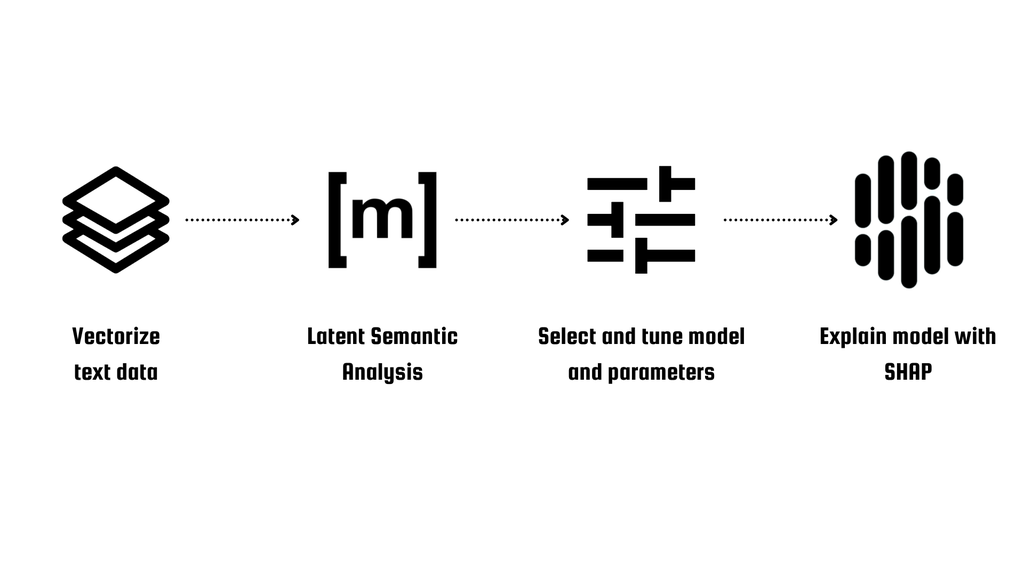

```python
Image('Methodology - Global.png')
```

**Figure 1. Global explainability methodology.**

Depending on the scope of explainability, the methodology used differs.

For global explainability, we use the pipeline above.

1. **Vectorize text data.** The review data needs to be vectorized to be able to pass it through a model. TF-IDF was the chosen model due to token (words) weights being scaled against its importance in the whole corpus.
2. **Latent Semantic Analysis.** Latent Semantic Analysis (LSA) is the application of Singular Value Decomposition (SVD) on text data to determine the underlying topics in the corpus.
3. **Model Selection and Hyperparameter Tuning.** This is considered as a classification problem, thus classification mdoels were used and tuned.
4. **Explainability with SHAP.** Summary Plots were used to produce the topics. The most prominent words under each were then interpreted.

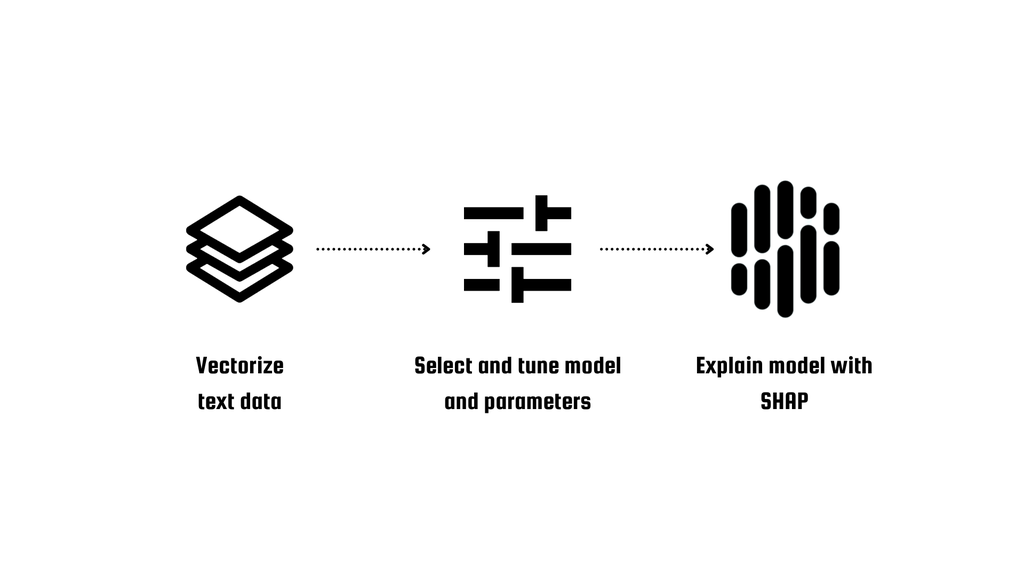

```python
Image('Methodology - Local.png')
```

**Figure 2. Local explainability methodology.**

Depending on the scope of explainability, the methodology used differs.

For local explainability, it shares similar steps with global except for LSA so that words are not grouped into topics and we can see how words contribute to the prediction. LSA also allows for words to be shared in different topics which makes interpreting individual reviews harder.

1. **Vectorize text data.**
2. **Model Selection and Hyperparameter Tuning**
3. **Explainability with SHAP**

Force plots for sample reviews were created and interpreted .

## 5. Dataset and Data Cleaning

```python
# general
import pandas as pd
import numpy as np
import matplotlib.pyplot as plt
import time

# Exploratory Data Analysis
from wordcloud import WordCloud, STOPWORDS

# text pre-processing
import re, string
import nltk
from nltk.tokenize import word_tokenize
from nltk.corpus import stopwords
from nltk.tokenize import word_tokenize
from nltk.corpus import wordnet
from nltk.stem import WordNetLemmatizer

# for model-building
from sklearn.pipeline import Pipeline
from sklearn.model_selection import KFold, GridSearchCV, train_test_split
from sklearn.feature_extraction.text import TfidfVectorizer, CountVectorizer

from sklearn.ensemble import RandomForestClassifier, GradientBoostingClassifier
from sklearn.linear_model import LogisticRegression, SGDClassifier
from sklearn.naive_bayes import GaussianNB

from sklearn.metrics import classification_report, accuracy_score, recall_score

from sklearn.decomposition import TruncatedSVD

# explainability
import shap
import colorama
from colorama import Fore, Back, Style
```

[output not shown]

### Dataset Description

The dataset was scraped from Amazon and is available on Jojie. The products are under the Digital Video Games category. It is composed 144724 reviews from 2006 to 2015. The columns we will mainly be looking at are `helpful_votes`, `verified_purchase`, `review_body` and `review_date`.

| Variable | Description |
| --- | --- |
| helpful_votes | The sum of all votes of whether a customer found a review helpful or not. A customer can only upvote a review and has only one vote per review. |
| verified_purchase | Variable describing whether or not a purchase was verified or received by the customer. |
| review_body | The actual text content of the review. |
| review_date | The date the review was posted. |

```python
path = '/mnt/data/public/amazon-reviews/'
file = 'amazon_reviews_us_Digital_Video_Games_v1_00.tsv.gz'
data = pd.read_csv(path + file, compression='gzip', sep='\t', quotechar='"')
df = data.copy()
display(df.head())
```

|  | marketplace | customer_id | review_id | product_id | product_parent | product_title | product_category | star_rating | helpful_votes | total_votes | vine | verified_purchase | review_headline | review_body | review_date |
| --- | --- | --- | --- | --- | --- | --- | --- | --- | --- | --- | --- | --- | --- | --- | --- |
| 0 | US | 21269168 | RSH1OZ87OYK92 | B013PURRZW | 603406193 | Madden NFL 16 - Xbox One Digital Code | Digital_Video_Games | 2 | 2 | 3 | N | N | A slight improvement from last year. | I keep buying madden every year hoping they ge... | 2015-08-31 |
| 1 | US | 133437 | R1WFOQ3N9BO65I | B00F4CEHNK | 341969535 | Xbox Live Gift Card | Digital_Video_Games | 5 | 0 | 0 | N | Y | Five Stars | Awesome | 2015-08-31 |
| 2 | US | 45765011 | R3YOOS71KM5M9 | B00DNHLFQA | 951665344 | Command & Conquer The Ultimate Collection [Ins... | Digital_Video_Games | 5 | 0 | 0 | N | Y | Hail to the great Yuri! | If you are prepping for the end of the world t... | 2015-08-31 |
| 3 | US | 113118 | R3R14UATT3OUFU | B004RMK5QG | 395682204 | Playstation Plus Subscription | Digital_Video_Games | 5 | 0 | 0 | N | Y | Five Stars | Perfect | 2015-08-31 |
| 4 | US | 22151364 | RV2W9SGDNQA2C | B00G9BNLQE | 640460561 | Saints Row IV - Enter The Dominatrix [Online G... | Digital_Video_Games | 5 | 0 | 0 | N | Y | Five Stars | Awesome! | 2015-08-31 |

## 6. Data Cleaning

### Filtering

Because we will be dealing with text data, it would be best to reduce the dataset else we will have unreasonably long run times.

1. Only verified purchases were considered as these would be the only legitimate reviews.
2. Review dates from 2013 onwards only were considered.
3. Only reviews with at least one helpful vote were considered. The rationale is to remove the bias of **unseen** reviews being marked as unhelpful. The dataset also has a majority of zero helpful votes. In this way, with at least 1 vote, we can say that a review was seen but not heplful enough for other users, hence they did not vote more on it. Users are capable of giving large numbers of votes based on the distribution of votes in the next section. It would be apt to call the class `least helpful` rather than unhelpful.

```python
# remove non-verified purchases and zero helpful votes
df = df[df['verified_purchase'] == 'Y']
df = df[df['helpful_votes'] > 0]

# convert review_dates to year
df['review_date'] = df['review_date'].str[0:4]
df = df.dropna(axis=0)
df['review_date'] = df['review_date'].astype(int)

# select only reviews greater than 2012
df = df[df['review_date'] > 2012]

display(df.head())
```

|  | marketplace | customer_id | review_id | product_id | product_parent | product_title | product_category | star_rating | helpful_votes | total_votes | vine | verified_purchase | review_headline | review_body | review_date |
| --- | --- | --- | --- | --- | --- | --- | --- | --- | --- | --- | --- | --- | --- | --- | --- |
| 46 | US | 30680101 | R1IMWXLSA5GWZU | B00QXRAL3U | 327387772 | SPIDERS RPG PACK [Online Game Code] | Digital_Video_Games | 3 | 1 | 1 | N | Y | Bad games, that become somewhat enjoyable. | This is a nice collection of RPGs, if you know... | 2015 |
| 57 | US | 9095823 | R2642823GCWLND | B011WI7U0G | 864854550 | Batman: Arkham Knight: A Matter Of Family - PS... | Digital_Video_Games | 3 | 1 | 1 | N | Y | Three Stars | It's easily better than the Harley Quinn dlc a... | 2015 |
| 60 | US | 7100361 | R2AOPNDW6ZWIRN | B014592BBC | 384652042 | Until Dawn - PlayStation 4 [Digital Code] | Digital_Video_Games | 5 | 1 | 2 | N | Y | Amazing graphics Amazing story Amazing gameplay | This game is beautiful and full of surprises! ... | 2015 |
| 62 | US | 11388778 | R1XITDEG13VYCE | B010O9XWO2 | 694952333 | King's Quest Collection | Digital_Video_Games | 1 | 2 | 12 | N | Y | One Big Mistake! | Can't get in to it due to the fact that you ha... | 2015 |
| 69 | US | 373926 | R2IWG7VDOCXK5U | B00D3TRMEM | 999316107 | Don't Starve | Digital_Video_Games | 5 | 1 | 1 | N | Y | Five Stars | Very nice but it now. Come with don't starve t... | 2015 |

### Cleaning

Here is a description of the numerical data. The number of helpful votes of a single product can really vary with the max being 5068 and the standard deviation being 39.

```python
display(df.describe())
```

|  | customer_id | product_parent | star_rating | helpful_votes | total_votes | review_date |
| --- | --- | --- | --- | --- | --- | --- |
| count | 2.231100e+04 | 2.231100e+04 | 22311.000000 | 22311.000000 | 22311.000000 | 22311.000000 |
| mean | 2.580951e+07 | 4.822388e+08 | 3.161535 | 3.334185 | 5.858949 | 2013.719062 |
| std | 1.560931e+07 | 2.829335e+08 | 1.730935 | 39.052464 | 42.979367 | 0.750947 |
| min | 1.226700e+04 | 4.000790e+05 | 1.000000 | 1.000000 | 1.000000 | 2013.000000 |
| 25% | 1.260801e+07 | 2.423740e+08 | 1.000000 | 1.000000 | 1.000000 | 2013.000000 |
| 50% | 2.352765e+07 | 4.147026e+08 | 4.000000 | 1.000000 | 2.000000 | 2014.000000 |
| 75% | 4.054372e+07 | 7.171791e+08 | 5.000000 | 3.000000 | 5.000000 | 2014.000000 |
| max | 5.309389e+07 | 9.996412e+08 | 5.000000 | 5068.000000 | 5251.000000 | 2015.000000 |

There are no null values.

```python
display(df.isnull().sum())
```

```
marketplace          0
customer_id          0
review_id            0
product_id           0
product_parent       0
product_title        0
product_category     0
star_rating          0
helpful_votes        0
total_votes          0
vine                 0
verified_purchase    0
review_headline      0
review_body          0
review_date          0
dtype: int64
```

Columns are either text or integers.

```python
display(df.dtypes)
```

```
marketplace          object
customer_id           int64
review_id            object
product_id           object
product_parent        int64
product_title        object
product_category     object
star_rating           int64
helpful_votes         int64
total_votes           int64
vine                 object
verified_purchase    object
review_headline      object
review_body          object
review_date           int64
dtype: object
```

## 7. Exploratory Data Analysis

The distribution of dates for the reviews. 2013 has the highest number. 2015 has the least but the year was also not completed.

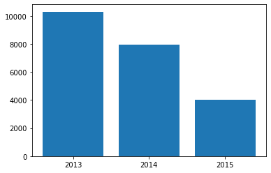

```python
plt.bar(['2013', '2014', '2015'], df['review_date'].value_counts())
plt.show()
```

The distribution of helpful and least helpful votes. The distribution is almost equal.

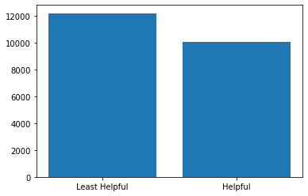

```python
# create target column
df['target'] = (df[['helpful_votes']] > 1) * 1

# plot distribution of helpful and least helpful votes.
plt.bar(['Least Helpful', 'Helpful'], df['target'].value_counts())
plt.show()
```

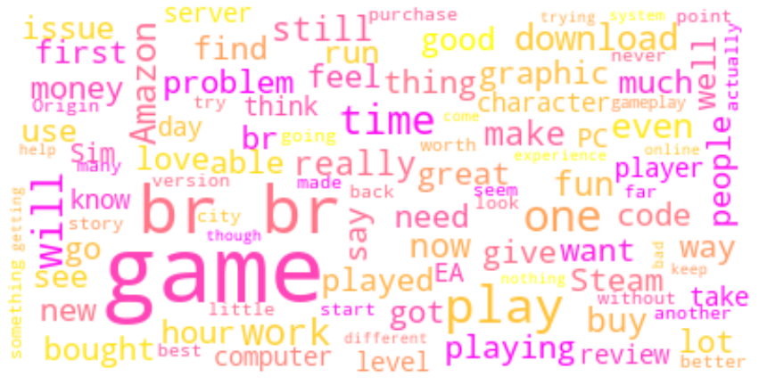

```python
helpful = WordCloud(max_font_size=50, max_words=100,
                      background_color="white", colormap='spring')
helpful.generate(df[df['target'] == 1]['review_body'].str.cat())
plt.figure(figsize=(15,10))
plt.imshow(helpful, interpolation="bilinear")
plt.axis("off")
plt.show()
```

Plotting a word cloud of the `helpful` class, we see prominent words such as `game`, `money`, `Amazon`, `play` and `great`. We need to determine how helpful these words are using the model. But these words generall refer to different customer touch points with an online digital game purchase website.

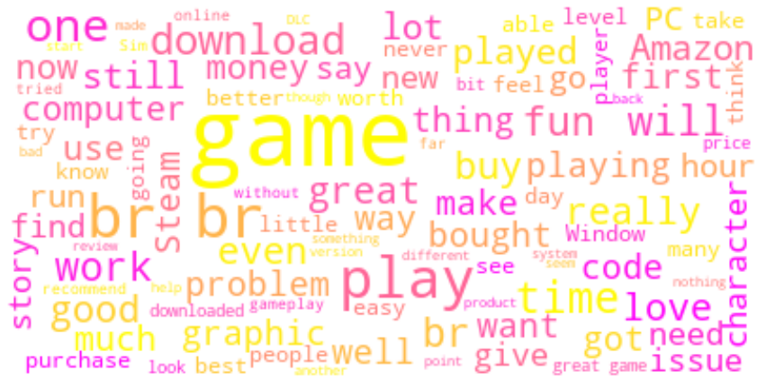

```python
lhelpful = WordCloud(max_font_size=50, max_words=100,
                      background_color="white", colormap='spring')
lhelpful.generate(df[df['target'] == 0]['review_body'].str.cat())
plt.figure(figsize=(15,10))
plt.imshow(lhelpful, interpolation="bilinear")
plt.axis("off")
plt.show()
```

Plotting a word cloud of the `least helpful` class, we see prominent words such as `game`, `money`, `download`, `play` and `problem`. These are very similar to the other class thus a model should be employed to distinguish their helpfulness.

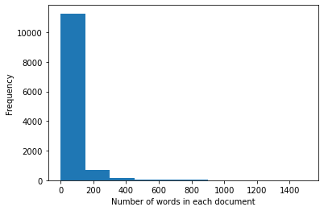

```python
plt.hist(df[df['target'] == 0]['review_body'].str.split().str.len(),
         bins=10, range=(0, 1500))
plt.xlabel('Number of words in each document')
plt.ylabel('Frequency')
plt.show()
```

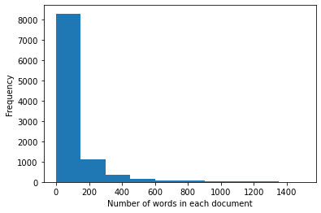

```python
plt.hist(df[df['target'] == 1]['review_body'].str.split().str.len(),
         bins=10, range=(0, 1500));
plt.xlabel('Number of words in each document')
plt.ylabel('Frequency')
plt.show()
```

The distribution of number of tokens per document in either class is similar.

## 8. Text Preprocessing

### Set target and features

We set the `review_body` as the feature and whether or not it was helpful as the `target`.

```python
X = df['review_body']
y = df['target']
```

### Preprocessing Functions

Text needs to be preprocessed before being vectorized. This involves cleaning of unwanted symbols, making everything lowercase, removing stopwords (common English words), and lemmatizing the words (mapping them to their root word). [2]

```python
#convert to lowercase, strip and remove punctuations
def preprocess(text):
    text = text.lower()
    text = text.strip()
    text = re.compile('<.*?>').sub('', text)
    text = re.compile('[%s]' % re.escape(string.punctuation)).sub(' ', text)
    text = re.sub('\s+', ' ', text)
    text = re.sub(r'\[[0-9]*\]',' ',text)
    text = re.sub(r'[^\w\s]', '', str(text).lower().strip())
    text = re.sub(r'\d',' ',text)
    text = re.sub(r'\s+',' ',text)
    return text

# remove stopwords
def stopword(string):
    a = [i for i in string.split() if i not in stopwords.words('english')]
    return ' '.join(a)

# lemmatization
# Initialize the lemmatizer
wl = WordNetLemmatizer()
def lemmatizer(string):

    def get_wordnet_pos(tag):
        if tag.startswith('J'):
            return wordnet.ADJ
        elif tag.startswith('V'):
            return wordnet.VERB
        elif tag.startswith('N'):
            return wordnet.NOUN
        elif tag.startswith('R'):
            return wordnet.ADV
        else:
            return wordnet.NOUN

    word_pos_tags = nltk.pos_tag(word_tokenize(string))
    a = [wl.lemmatize(tag[0], get_wordnet_pos(tag[1]))
         for idx, tag in enumerate(word_pos_tags)]
    if len(a) > 2:
        return " ".join(a)

# final preprocessing function
def finalpreprocess(string):
    return lemmatizer(stopword(preprocess(string)))
```

### Apply preprocessing function on corpus

Preprocessing takes a while so the processed text data was saved as a new csv file for easier access.

```python
# X = X.apply(lambda x: finalpreprocess(x))
# X.to_csv('cleaned_text.csv', index=False)
# X.head()
```

## 9. Model Training

### Load cleaned text data

The data from the csv file was loaded as the new feature.

```python
X = pd.read_csv('cleaned_text.csv')['review_body'].astype(str)
display(X.head())
```

```
0    nice collection rpgs know get clear research g...
1            easily well harley quinn dlc red hood dlc
2    game beautiful full surprise never story twice...
3    get due fact use arrow key move around disappo...
4                       nice come starve together code
Name: review_body, dtype: object
```

### Applying the vectorized data directly into model

```python
cols = ['mean_test_score', 'params']
def classify_linear(model, X, y):
    start_time = time.time()

    # hyperparameters
    alpha_range = [1e-3, 0.01, 0.1, 1, 100, 1000]
    if model[0] == 'LogReg':
        params = {model[0]+'__C': alpha_range}
    else:
        params = {model[0]+'__alpha': alpha_range}

    # cross-validation settings
    kf = KFold(n_splits=5)

    # vectorizer
    vectorizer = ('vectorizer', TfidfVectorizer(stop_words='english',
                                                max_df=0.7, min_df=0.001))
    pipeline = Pipeline([vectorizer, model])

    # gridsearch
    cv = GridSearchCV(estimator=pipeline, param_grid=params, cv=kf,
                      scoring='recall').fit(X, y)
    res = pd.DataFrame(cv.cv_results_, columns=cols)
    res = res.loc[cv.best_index_]
    res['time'] = (time.time() - start_time)
    return res.values

def classify_tree(model, X, y):
    start_time = time.time()

    # hyperparameters
    features_tuning = [0.1, 0.2, 0.5, 0.8]
    params = {model[0]+'__max_features': features_tuning}

    # cross-validation settings
    kf = KFold(n_splits=5)

    # scaler
    vectorizer = ('vectorizer', TfidfVectorizer(stop_words='english',
                                                max_df=0.7, min_df=0.001))
    pipeline = Pipeline([vectorizer, model])

    cv = GridSearchCV(estimator=pipeline, param_grid=params, cv=kf,
                      scoring='recall').fit(X, y)
    res = pd.DataFrame(cv.cv_results_, columns=cols)
    res = res.loc[cv.best_index_]
    res['time'] = (time.time() - start_time)
    return res.values
```

```python
results = pd.DataFrame([
    classify_linear(('LogReg', LogisticRegression(solver='sag', penalty='l2',
                                                  max_iter=1e7, n_jobs=-1,
                                                  random_state=42)), X, y),
    classify_linear(('SDG', SGDClassifier(max_iter=1e7, n_jobs=-1,
                                          random_state=42)), X, y),
    # classify_tree(('RF', RandomForestClassifier(n_jobs=-1)), X, y),
    classify_tree(('GBM', GradientBoostingClassifier(random_state=42)), X, y)
        ], columns=['Test Score', 'Best Parameter', 'Run Time'],
           index=['Logistic Regression', 'SGDClassifier',
                  # 'Random Forest',
                  'Gradient Boosting'])

X1 = X.copy().reset_index(drop=True)
y1 = y.copy().reset_index(drop=True)
res = []

start_time = time.time()
for train_idx, test_idx in KFold(n_splits=5).split(X1):

    X_train, X_test = X1[train_idx], X1[test_idx]
    y_train, y_test = y1[train_idx], y1[test_idx]

    vectorizer = TfidfVectorizer(stop_words='english', max_df=0.7, min_df=0.001)
    X_train_vec = vectorizer.fit_transform(X_train).toarray()
    X_test_vec = vectorizer.transform(X_test).toarray()

    gnb = GaussianNB().fit(X_train_vec, y_train)
    y_pred = gnb.predict(X_test_vec)
    res.append(recall_score(y_test, y_pred))


display(results.append(pd.DataFrame([[np.mean(res), None, time.time() -
                                      start_time]],
                       columns=['Test Score', 'Best Parameter', 'Run Time'],
                       index=['GaussianNB'])))
```

|  | Test Score | Best Parameter | Run Time |
| --- | --- | --- | --- |
| Logistic Regression | 0.471224 | {'LogReg__C': 1000} | 60.864282 |
| SGDClassifier | 0.800000 | {'SDG__alpha': 100} | 26.489090 |
| Gradient Boosting | 0.347935 | {'GBM__max_features': 0.8} | 162.845780 |
| GaussianNB | 0.448547 | None | 12.179868 |

The classification models considered were `Logistic Regression`, `Stochastic Gradient Descent Classifier`, `Random Forest` (which is now commented out for reproducibility as it takes about 45mins to train), `Gradient Boosting Method` and `Gaussian Naive Bayes`.

Connecting with the rationale in filtering, the test score is **recall**. Since technically all reviews have at least one helpful vote, there is a reason to say all are relevant. Thus, being able to identify the true positives or relevant data out was the metric of choice.

The data was first split into train and test sets before they were vectorized. This is implemented using the `Pipeline` class in `sklearn`. Including the vectorization in the train test split reduces information of test set bleeding into the train set although it will increase run time.

### Select best model

The best model is the `SGD Classifier` with a test score of 0.80. SGD Classifier is a regularized linear model with stochastic gradient descent learning. With some hyperparameter settings, it will act like a linear Support Vector Machine (SVM).

## 10. Explaining the Model

To interpret the model, we instantiate the model to be fed into SHAP. The recall at this instance is lower than the average recall.

```python
X_train, X_test, y_train, y_test = train_test_split(X, y, test_size=0.20, random_state=42)

vectorizer = TfidfVectorizer(stop_words='english', max_df=0.7, min_df=0.001)
X_train_vec = vectorizer.fit_transform(X_train)
X_test_vec = vectorizer.transform(X_test)
vocab = vectorizer.get_feature_names()

model = SGDClassifier(max_iter=1e7, alpha=0.001, n_jobs=-1, random_state=42)
model.fit(X_train_vec, y_train)

y_pred = model.predict(X_test_vec)
print('recall:', recall_score(y_pred, y_test))
```

```
recall: 0.7085889570552147
```

### Classification Report

If we used other metrics, predicting the target class would have had lower test scores.

```python
print(classification_report(y_pred, y_test))
```

```
              precision    recall  f1-score   support

           0       0.92      0.59      0.72      3811
           1       0.23      0.71      0.35       652

    accuracy                           0.61      4463
   macro avg       0.58      0.65      0.53      4463
weighted avg       0.82      0.61      0.67      4463
```

### Model Coefficients

From the model coefficients, we see the following tokens (words). These are tokens with the largest weight in the model.

```python
top = sorted(zip(sorted(vectorizer.vocabulary_.keys()), model.coef_[0]), key=lambda x: -abs(x[1]))
top[:10]
```

```
[('review', 1.5453381071250405),
 ('ea', 1.5194540840747068),
 ('city', 1.5069966147387046),
 ('server', 1.4702243290471726),
 ('steam', 1.382457921699828),
 ('amazon', 1.165164430440682),
 ('release', 1.1269290287965286),
 ('origin', 1.0897878755376011),
 ('support', 1.0332167933717762),
 ('issue', 0.9780523409454825)]
```

See below, this is a very simple explainability graph as compared to using SHAP.

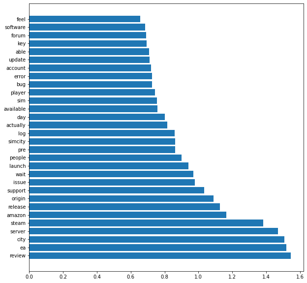

```python
plt.figure(figsize=(10,10))
plt.barh([i[0] for i in top[:30]], [i[1] for i in top[:30]]);
```

### SHAP Applications

```python
explainer = shap.LinearExplainer(
    model, shap.maskers.Independent(data=X_train_vec.toarray()))
shap_values = explainer(X_train_vec.toarray())
```

### Global Explainability

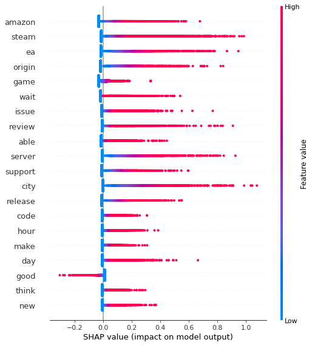

```python
shap.summary_plot(shap_values, max_display=20, feature_names=vocab)
```

Interpretations:

- Brand names such as `amazon`, `steam` and `ea` top the list. These words increase the helpfulness of a review.
- `wait` can refer to either waiting off to buy the game. Wait times in downloading or playing online (including 'server') can also be relevant. This is also considered helpful for other customers to know.

For global explainability, it would be better to group words as manually clustering them based on their definitions is inefficient and time consuming. This pipeline is better to be used in Local explainability.

### Local Explainability

In natural language processing, the easiest and most common way to determine local explainability is to get the cumulative weights of tokens in a certain document. Luckily, this is how SHAP already does local explainability using the Force plot however it uses shapley values instead of just the feature weights.

The visualizations below can also be accomplished using the `plot.text` SHAP function. However this requires the use of models and libraries outside of the scope of the project.

```python
def print_shap_contrib(review, shpvs):

    feature_importance = pd.DataFrame(list(zip(shpvs, vocab)),
                                      columns=['shap_vals', 'word'])
    feature_importance.sort_values(by=['shap_vals'], ascending=False, inplace=True)
    feature_importance = feature_importance.head(30).append(feature_importance.tail(30))
    feature_importance = feature_importance.set_index('word')
    text = ''
    for i in review.split():
        if i in feature_importance.index:
            if feature_importance.loc[i]['shap_vals'] > 0:
                text += (Fore.RED + Style.BRIGHT + i)
            else:
                text += (Fore.BLACK + Style.RESET_ALL + i)
        else:
            text += (Fore.BLACK + Style.RESET_ALL + i)
        text += ' '
    print(text)
```

### Sample Review 1

```
nothing wrong game use origin install software every game company near future go silly could stick steam digital download site like maybe amazon make u install crap software sell u garbage game download personal info computer fine thanx ea
```

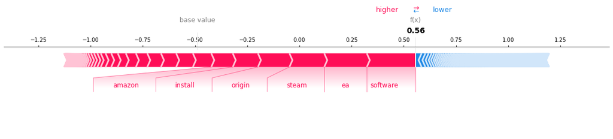

```python
shpvs = shap_values[17].values
print_shap_contrib(X_train.loc[17681], shpvs)
shap.force_plot(explainer.expected_value, shpvs, vocab, matplotlib=True)
```

(Printing of text may change depending on the Jupyter theme used whether in Lab or Notebook.)

Red words are considered what makes the review helpful. The force plot below shows how the weights of the tokens contribute to the overall helpfulness of the review.

In this case, the sentence "amazon makes u install crap software sell u garbage game" is negative yet helpful.

### Sample Review 2

```
ea support pas responsibility onto amazon amazon refund play offline impedes large portion game original capability game activate ea origin support agent however second activation gaininternet access apparently remove server thus error message return state user nothave proper spore privilege key pro…
```

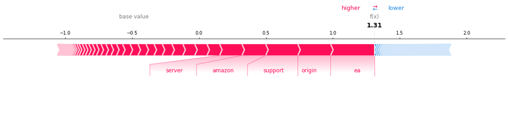

```python
shpvs = shap_values[19].values
print_shap_contrib(X_train.loc[22183], shpvs)
shap.force_plot(explainer.expected_value, shpvs, vocab, matplotlib=True)
```

For this review we see that the topics include refunds, support and activation of the game. These contribute to the comprehensiveness of the review and so this review is considered very helpful.

## 11. Including Latent Semantic Analysis in the Pipeline

In terms of global explainability, it is better to include LSA in the pipeline. This allows for underlying topics to emerge from the corpus. According to `sklearn` documentation, the recommended number of components for LSA is `n = 100`.

```python
cols = ['mean_test_score', 'params']
def classify_linear(model, X, y):
    start_time = time.time()

    # hyperparameters
    alpha_range = [1e-3, 0.01, 0.1, 1, 100, 1000]
    if model[0] == 'LogReg':
        params = {model[0]+'__C': alpha_range}
    else:
        params = {model[0]+'__alpha': alpha_range}

    # cross-validation settings
    kf = KFold(n_splits=5)

    # vectorizer
    vectorizer = ('vectorizer', TfidfVectorizer(stop_words='english',
                                                max_df=0.7, min_df=0.001,
                                                sublinear_tf=True, use_idf=True))
    svd = ('svd', TruncatedSVD(n_components=100, random_state=42))
    pipeline = Pipeline([vectorizer, svd, model])

    # gridsearch
    cv = GridSearchCV(estimator=pipeline, param_grid=params, cv=kf,
                      scoring='recall').fit(X, y)
    res = pd.DataFrame(cv.cv_results_, columns=cols)
    res = res.loc[cv.best_index_]
    res['time'] = (time.time() - start_time)
    return res.values

def classify_tree(model, X, y):
    start_time = time.time()

    # hyperparameters
    features_tuning = [0.1, 0.2, 0.5, 0.8]
    params = {model[0]+'__max_features': features_tuning}

    # cross-validation settings
    kf = KFold(n_splits=5)

    # scaler
    vectorizer = ('vectorizer', TfidfVectorizer(stop_words='english',
                                                max_df=0.7, min_df=0.001,
                                                sublinear_tf=True, use_idf=True))
    svd = ('svd', TruncatedSVD(n_components=100, random_state=42))
    pipeline = Pipeline([vectorizer, svd, model])

    cv = GridSearchCV(estimator=pipeline, param_grid=params, cv=kf,
                      scoring='recall').fit(X, y)
    res = pd.DataFrame(cv.cv_results_, columns=cols)
    res = res.loc[cv.best_index_]
    res['time'] = (time.time() - start_time)
    return res.values
```

```python
results = pd.DataFrame([
    classify_linear(('LogReg', LogisticRegression(solver='sag', penalty='l2',
                                                  max_iter=1e7, n_jobs=-1,
                                                  random_state=42)), X, y),
    classify_linear(('SDG', SGDClassifier(max_iter=1e7, n_jobs=-1,
                                          random_state=42)), X, y),
    # remove RF models since it takes too long
    # classify_tree(('RF', RandomForestClassifier(n_jobs=-1)), X, y),
    classify_tree(('GBM', GradientBoostingClassifier(random_state=42)), X, y)
                        ],
    columns=['Test Score', 'Best Parameter', 'Run Time'],
    index=['Logistic Regression', 'SGDClassifier',
           # 'Random Forest',
           'Gradient Boosting'
          ])

X1 = X.copy().reset_index(drop=True)
y1 = y.copy().reset_index(drop=True)
res = []

start_time = time.time()
for train_idx, test_idx in KFold(n_splits=5).split(X1):

    X_train, X_test = X1[train_idx], X1[test_idx]
    y_train, y_test = y1[train_idx], y1[test_idx]

    vectorizer = TfidfVectorizer(stop_words='english', max_df=0.7, min_df=0.001)
    X_train_vec = vectorizer.fit_transform(X_train).toarray()
    X_test_vec = vectorizer.transform(X_test).toarray()

    svd = TruncatedSVD(n_components=100, random_state=42)
    X_train_svd = svd.fit_transform(X_train_vec)
    X_test_svd = svd.transform(X_test_vec)

    gnb = GaussianNB().fit(X_train_svd, y_train)
    y_pred = gnb.predict(X_test_svd)
    res.append(recall_score(y_test, y_pred))

display(results.append(pd.DataFrame([[np.mean(res), None, time.time() - start_time]],
                       columns=['Test Score', 'Best Parameter', 'Run Time'],
                       index=['GaussianNB'])))
```

|  | Test Score | Best Parameter | Run Time |
| --- | --- | --- | --- |
| Logistic Regression | 0.430185 | {'LogReg__C': 1000} | 194.567855 |
| SGDClassifier | 0.800000 | {'SDG__alpha': 100} | 167.892799 |
| Gradient Boosting | 0.415338 | {'GBM__max_features': 0.8} | 790.053997 |
| GaussianNB | 0.709772 | None | 85.016158 |

Again, the same models were used (and Random Forest has again been commented out due to run time). This time we see an increase in the run time with the inclusion of LSA at every train-test split.

We see that the best model again is `SGD Classifier` with a test score of 0.80.

### Select the best model

```python
X1 = X.copy().reset_index(drop=True)
y1 = y.copy().reset_index(drop=True)

X_train, X_test, y_train, y_test = train_test_split(X1, y1, test_size=0.20,
                                                    random_state=42)

vectorizer = TfidfVectorizer(stop_words='english', max_df=0.7, min_df=0.001,
                             sublinear_tf=True, use_idf=True)
X_train_vec = vectorizer.fit_transform(X_train)
X_test_vec = vectorizer.transform(X_test)
vocab = vectorizer.get_feature_names()

svd = TruncatedSVD(n_components=100, random_state=42)
X_train_svd = svd.fit_transform(X_train_vec)
X_test_svd = svd.transform(X_test_vec)

model = SGDClassifier(max_iter=1e7, alpha=0.001, n_jobs=-1, random_state=42)
model.fit(X_train_svd, y_train)

y_pred = model.predict(X_test_svd)
print('recall:', recall_score(y_pred, y_test))
```

```
recall: 0.712166172106825
```

```python
print(classification_report(y_pred, y_test))
```

```
              precision    recall  f1-score   support

           0       0.92      0.59      0.72      3789
           1       0.24      0.71      0.36       674

    accuracy                           0.61      4463
   macro avg       0.58      0.65      0.54      4463
weighted avg       0.82      0.61      0.67      4463
```

Again, we use an instance of the `SGD Classifier` model for explainability. Recall again is the better metric again for predicting the helpful class.

## 12. Explainability of LSA model

```python
for topic_idx, topic in enumerate(svd.components_[:10]):
    message = "Topic #%d: " % topic_idx
    message += ", ".join([vocab[i] for i in topic.argsort()[:-10 -1:-1]])
    print(message)
```

```
Topic #0: nan, end, far, slow, thanks, kid, ok, ps, point, thing
Topic #1: game, play, download, work, like, great, buy, time, good, fun
Topic #2: code, work, download, amazon, buy, steam, money, purchase, waste, refund
Topic #3: code, work, card, great, use, redeem, good, xbox, buy, enter
Topic #4: great, love, game, download, fun, code, steam, work, easy, price
Topic #5: work, window, waste, money, computer, fun, time, play, try, game
Topic #6: money, waste, buy, love, play, worth, game, want, time, code
Topic #7: great, buy, good, price, steam, money, graphic, deal, work, worth
Topic #8: good, download, money, fun, like, waste, code, really, object, easy
Topic #9: love, buy, good, work, game, like, computer, sims, version, son
```

Since we have topics, it would be best to look at the words comprising each topic for interpretation.

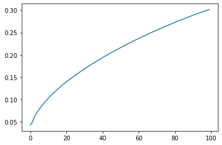

```python
plt.plot(svd.explained_variance_ratio_.cumsum());
```

For 100 components, the LSA model only captured about 30% of the variance of the whole TF-IDF matrix.

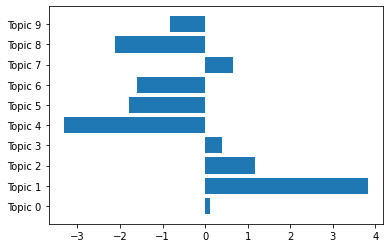

```python
plt.barh([('Topic ' + str(i)) for i in range(0,10)], width=model.coef_[0][:10]);
```

Here we see the topics and their weights in the model from the coefficients frmo the model class. This is can be improved using SHAP.

```python
explainer = shap.LinearExplainer(model, shap.maskers.Independent(data=X_train_svd))
shap_values = explainer(X_train_svd)
```

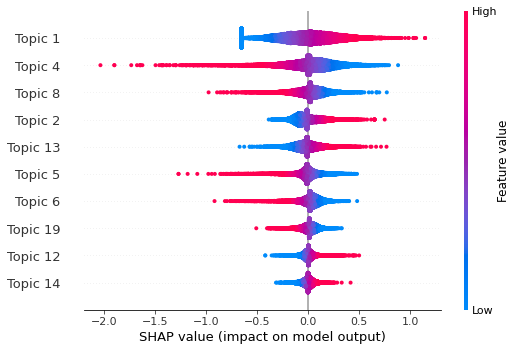

```python
shap.summary_plot(shap_values, max_display=10, feature_names=[('Topic ' + str(i)) for i in range(0,100)])
```

We see that by using SHAP and LSA, we improved our global explainability. We see that topics can determine helpfulness. Let's look at some topics and how they positively affect the model.

**Topic #1: game, play, download, work, like, great, buy, time, good, fun**

Topic 1 represents the general customer experience of the video game from purchase to play. Reviews with this topic will positively influence its helpfulness.

**Topic #2: code, work, download, amazon, buy, steam, money, purchase, waste, refund**

Topic 2 represents the financial worth of the game. Money, puchase, waste and refund all refer to purchasing the game and is very helpful for other customers because it gives them more information that cannot be immediately seen unless you play the game.

## 13. Conclusion

SHAP is a powerful library that allows for both local and global scope of explainability. However, when dealing with text data, there can be different approaches in local and global explainability.

Global explainability methods benefit from decomposition methods as the underlying themes are more representative of the corpus rather than manually clustering the words by interpretation. In terms of digital video games, topics such as the general experience and worth of the game positively contribute to its helpfulness. Therefore, these are the kidns of reviews that should be boosted on the platform. These topics can also be set as preferred talking points in the platform's content guidelines to generate better reviews.

For local explainability, the use of decompostiion methods such as LSA may reduce the individual token interpretability as they are hidden behind topics. A pipeline like this also means that the original document goes through more transformations which may render the meaning incomprehensible at the end. The model allows for a single review to go through only one transformation and be identified as helpful or not. This can be an added filter to helpful votes to verify if the review with a lots of votes is actually helpful.

## 14. Recommendations

1. Models which capture token relationships better such as neural networks will give better test scores, thus better explainability in SHAP. These models may also be compatible with SHAP's `plot.text` function which offers a better visualization than manually coding.
2. Other methods of decomposition may be employed to give better test scores. A higher number of components may improve the score as well however may increase run time further.
3. Using other metrics may also be considered in training such as F1-score or AUC-ROC.
4. Clustering of topics/tokens may also be done as the summary plot of SHAP allows this. However, this was not employed in this study due to the high dimensionality of the dataset and the increase in run time.
5. Improving the target definition such as using multiple levels of helpfulness based on the number of votes or even pivoting to a regression problem by the number of votes may be employed to improve the model.
6. Incorporating star rating and number of purchases in the dataset may also improve the model in determining helpfulness and may give more granular analysis in results.

## References

[1] Li, Mengxiang, et al. “Helpfulness of Online Product Reviews as Seen by Consumers: Source and Content Features.” International Journal of Electronic Commerce, vol. 17, no. 4, 2013, pp. 101–136., https://doi.org/10.2753/jec1086-4415170404.

[2] Rani, Vijaya. “NLP Tutorial for Text Classification in Python.” Medium, Analytics Vidhya, 4 Sept. 2021, https://medium.com/analytics-vidhya/nlp-tutorial-for-text-classification-in-python-8f19cd17b49e.

[3] ]Robinson, Sara. “Interpreting Bag of Words Models with Shap.” Sara Robinson, https://sararobinson.dev/2019/04/23/interpret-bag-of-words-models-shap.html.

[4] Zhao, Zhao, et al. "SHAP values for Explaining CNN-based Text Classification Models." Computation and Language, 2021.